# Assembling assays into a master `MultiAssayExperiment` object

### Creating the `visit`, `visit_number`, and `study_week` columns

```r
visit_dict <-
  bind_rows(
    tibble(
      visit = "Screening",
      definition = "Screening visit for which we have the most assay data. If two screening visits have the same number of assays, we take the last one.",
      possible_visit_codes = "0000, 0001, 0010, 0011",
      visit_number = "V0",
      study_week = -1
    ),
    tibble(
      visit = "Add. screening",
      definition = 'If a participant has data for two screening visits, one is the "main" screening visit, and the other is labelled as an additional screening visit.',
      possible_visit_codes = "0000, 0001, 0010, 0011",
      visit_number = "V0b",
      study_week = -2
    ),
    tibble(
      visit = "Day 0 (pre-MTZ)",
      definition = "Visit before the metronidazole treatment (MTZ) starts.",
      possible_visit_codes = "1000, 1011",
      visit_number = "V1",
      study_week = 0
    ),
    tibble(
      visit = "Week 1 (post-MTZ)",
      definition = "Visit after the metronidazole treatment (MTZ) ends.",
      possible_visit_codes = "1100",
      visit_number = "V2",
      study_week = 1
    ),
    tibble(
      visit = "Week 2 (post-SP)",
      definition = "Visit after the study product (SP) ends.",
      possible_visit_codes = "1200, 1211",
      visit_number = "V3",
      study_week = 2
    ),
    tibble(
      visit = "Week 3",
      definition = "Visit one week after the study product (SP) ends.",
      possible_visit_codes = "1300",
      visit_number = "V4",
      study_week = 3
    ),
    tibble(
      visit = "Week 4",
      definition = "Visit two weeks after the study product (SP) ends.",
      possible_visit_codes = "1400",
      visit_number = "V5",
      study_week = 4
    ),
    tibble(
      visit = "Week 5",
      definition = "Visit three weeks after the study product (SP) ends.",
      possible_visit_codes = "1500, 1511, 1512",
      visit_number = "V6",
      study_week = 5
    ),
    tibble(
      visit = "Week 7",
      definition = "Visit five weeks after the study product (SP) ends.",
      possible_visit_codes = "1700, 1711",
      visit_number = "V7",
      study_week = 7
    ),
    tibble(
      visit = "Week 9",
      definition = "Visit seven weeks after the study product (SP) ends.",
      possible_visit_codes = "1900, 1911",
      visit_number = "V8",
      study_week = 9
    ),
    tibble(
      visit = "Week 12",
      definition = "Visit ten weeks after the study product (SP) ends.",
      possible_visit_codes = "2120, 2121, 2122",
      visit_number = "V9",
      study_week = 12
    )
  ) |>
  mutate(
    visit = visit |> fct_reorder(study_week)
  )
```

```r
visit_dict |>
  gt() |>
  tab_header(
    title = "Visit codes and definitions"
  ) |>
  cols_label(
    visit = "Visit",
    definition = "Definition",
    possible_visit_codes = "Possible visit codes",
    visit_number = "Visit number",
    study_week = "Study week"
  ) |>
  cols_align(
    align = "left",
    columns = c(visit, definition, possible_visit_codes)
  )
```

Visit codes and definitions

| Visit | Definition | Possible visit codes | Visit number | Study week |
| --- | --- | --- | --- | --- |
| Screening | Screening visit for which we have the most assay data. If two screening visits have the same number of assays, we take the last one. | 0000, 0001, 0010, 0011 | V0 | -1 |
| Add. screening | If a participant has data for two screening visits, one is the "main" screening visit, and the other is labelled as an additional screening visit. | 0000, 0001, 0010, 0011 | V0b | -2 |
| Day 0 (pre-MTZ) | Visit before the metronidazole treatment (MTZ) starts. | 1000, 1011 | V1 | 0 |
| Week 1 (post-MTZ) | Visit after the metronidazole treatment (MTZ) ends. | 1100 | V2 | 1 |
| Week 2 (post-SP) | Visit after the study product (SP) ends. | 1200, 1211 | V3 | 2 |
| Week 3 | Visit one week after the study product (SP) ends. | 1300 | V4 | 3 |
| Week 4 | Visit two weeks after the study product (SP) ends. | 1400 | V5 | 4 |
| Week 5 | Visit three weeks after the study product (SP) ends. | 1500, 1511, 1512 | V6 | 5 |
| Week 7 | Visit five weeks after the study product (SP) ends. | 1700, 1711 | V7 | 7 |
| Week 9 | Visit seven weeks after the study product (SP) ends. | 1900, 1911 | V8 | 9 |
| Week 12 | Visit ten weeks after the study product (SP) ends. | 2120, 2121, 2122 | V9 | 12 |

We first determine, for each participant, which is their main *vs.* their additional screening visit.

```r
mae_coldata <-
  mae_coldata |>
  group_by(pid) |>
  mutate(
    is_screening_visit = case_when(
      visit_code %in% c("0000", "0001", "0010", "0011") ~ TRUE,
      TRUE ~ FALSE
    ),
    n_assays = ifelse(in_assays, str_split(assays, ", ") |> lengths(), 0),
    screening_visit_score = is_screening_visit * (n_assays + study_day / 10)
  ) |>
  arrange(-screening_visit_score) |>
  mutate(
    screening_visit = case_when(
      is_screening_visit & (row_number() == 1) ~ "main screening",
      is_screening_visit & (row_number() > 1) ~ "additional screening",
      TRUE ~ NA_character_
    )
  ) |>
  ungroup() |>
  select(-is_screening_visit, -n_assays, -screening_visit_score)
```

```r
mae_coldata |>
  dplyr::filter(screening_visit == "additional screening") |>
  select(pid) |>
  distinct() |>
  left_join(mae_coldata) |>
  arrange(randomized |> desc(), pid, visit_code) |>
  select(
    randomized,
    pid,
    visit_code,
    study_day,
    crf_plates,
    assays,
    screening_visit
  ) |>
  View()

mae_coldata |>
  dplyr::filter(screening_visit == "additional screening") |>
  select(pid) |>
  distinct() |>
  left_join(mae_coldata) |>
  arrange(randomized |> desc(), pid, visit_code) |>
  select(
    randomized,
    pid,
    visit_code,
    study_day,
    crf_plates,
    assays,
    screening_visit
  ) |>
  dplyr::filter(
    randomized,
    (screening_visit == "main screening"),
    study_day == 0
  ) |>
  select(pid) |>
  distinct() |>
  left_join(mae_coldata) |>
  arrange(randomized |> desc(), pid, visit_code) |>
  select(
    randomized,
    mITT,
    pid,
    visit_code,
    study_day,
    crf_plates,
    assays,
    screening_visit
  ) |>
  View()


# > check 068200020
# unclear - her main screening visit could be at day -3, but it might be at day 0, which would mean that her screening visit and pre-MTZ visit samples were collected on the same day
crf_raw$crf35 |> dplyr::filter(pid == "068200020") |> View()
```

```r
mae_coldata |>
  filter(!is.na(screening_visit)) |>
  dplyr::count(screening_visit)
```

```
# A tibble: 2 × 2
  screening_visit          n
  <chr>                <int>
1 additional screening    66
2 main screening         532
```

We next join the `mae_coldata` table with the `visit_dict` table to add the `visit`, `visit_number`, and `study_week` columns.

```r
mae_coldata <-
  mae_coldata |>
  select(-any_of(c("PIPV", "visit", "visit_number", "study_week"))) |>
  left_join(
    visit_dict |>
      mutate(visit_code = possible_visit_codes |> str_split(", ")) |>
      unnest(visit_code) |>
      mutate(
        screening_visit = case_when(
          visit_number == "V0b" ~ "additional screening",
          visit_number == "V0" ~ "main screening",
          TRUE ~ NA_character_
        ),
        PIPV = visit_number != "V0b"
      ) |>
      select(visit_code, screening_visit, PIPV, visit, visit_number, study_week)
  ) |>
  mutate(PIPV = PIPV |> replace_na(FALSE)) |>
  relocate(
    PIPV,
    visit,
    visit_number,
    study_week,
    .after = "visit_code"
  )
```

We check that `study_day`s are unique for each `visit_number` at which assay samples were collected for each participant.

```r
mae_coldata |>
  group_by(pid, visit_number) |>
  mutate(n_study_day = n_distinct(study_day[!is.na(assays)])) |>
  ungroup() |>
  filter(PIPV, n_study_day > 1) |>
  select(uid, pid, visit_code, study_day, assays) |>
  group_by(pid) |>
  gt(row_group_as_column = TRUE)
```

|  | uid | visit_code | study_day | assays |
| --- | --- | --- | --- | --- |
| 068200062 | 068200062_1500 | 1500 | 37 | mg, qPCR, amplicon_ASV, amplicon |
|  | 068200062_1511 | 1511 | 44 | luminex, flow |
| 068200087 | 068200087_1500 | 1500 | 40 | mg, qPCR, amplicon_ASV, amplicon, luminex |
|  | 068200087_1511 | 1511 | 43 | flow |

There are just two participants for which the dates don’t match and the different assays were collected at different dates. This may be important for integrative analyses later, so we leave as is for now.

### Creating the dictionary for the mae_coldata table

We create a dictionary to document the variables in the `mae_coldata` table, which will be useful for downstream analyses and for the data sharing.

We already have a dictionnary for the `participants` table (`participants_variable_dictionary`), we use this and add the variables from the `visits` table and the `mae_coldata_assays` table, as well as the variables we created in the previous steps (e.g., `visit`, `visit_number`, `study_week`, etc.).

```r
coldata_dictionary <-
  bind_rows(
    participants_variable_dictionary |> select(variable, description),
    tibble(
      variable = setdiff(colnames(mae_coldata), colnames(participants)),
      description = case_when(
        variable ==
          "uid" ~ "Unique identifier for each participant x visit combination, in the format `pid`_`visit_code`",
        variable == "PIPV" ~ "Planned in-person visit (PIPV) flag",
        variable == "visit_code" ~ "Visit code as in the CRF data",
        variable == "visit" ~ "Visit name (e.g., Screening, Week 1 (post-MTZ), etc.)",
        variable == "visit_number" ~ "Visit number (e.g., V0, V1, etc.)",
        variable ==
          "study_week" ~ "Study week number (from -2 to 12, with 0 being the day of the pre-MTZ visit)",
        variable ==
          "study_day" ~ "Relative study day number with 0 being the day of the pre-MTZ visit",
        variable ==
          "n_distinct_study_days" ~ "Number of distinct study days for a given participant and visit number",
        variable ==
          "crf_plates" ~ "CRF plates for which we have data for this participant x visit combination",
        variable ==
          "visit_attended" ~ "Whether the participant attended the visit according to the CRF data",
        variable == "visit_planned" ~ "Whether the visit was planned according to the CRF data",
        variable == "visit_type" ~ "Visit type (e.g., Clinic, Home, Unclear or NA)",
        variable == "in_CRF" ~ "Whether this participant x visit combination is in the CRF data",
        variable ==
          "in_assays" ~ "Whether this participant x visit combination is in an assay data",
        variable ==
          "sample_type" ~ "Sample type for this participant x visit combination in the assay data (Clinical sample, Clinical sample (other study), Negative/Positive control), Test sample or NA)",
        variable ==
          "control_type" ~ "Control type for the Negative and Positive control samples in the assay data (Nuclease-free water, Unused swab + C2, Mock 1 and Mock 2)",
        variable ==
          "assays" ~ "Names of the assays for which we have data for this participant x visit combination (mg, qPCR, amplicon, luminex, flow, etc.)",
        variable ==
          "screening_visit" ~ "Whether the visit is the main screening visit, an additional screening visit, or not a screening visit"
      )
    )
  )
```

```r
coldata_dictionary |>
  arrange(variable) |>
  gt() |>
  tab_header(
    title = "Dictionary for the mae_coldata table"
  ) |>
  cols_label(
    variable = "Variable",
    description = "Description"
  ) |>
  cols_align(
    align = "left",
    columns = variable
  )
```

Dictionary for the mae_coldata table

| Variable | Description |
| --- | --- |
| ITT | Intention-to-treat population flag (TRUE or FALSE) |
| PIPV | Planned in-person visit (PIPV) flag |
| PP | Per-protocol population flag (TRUE or FALSE) |
| any_HSIL | Whether participant had HSIL pap at screening visit. |
| any_antibiotics | Whether participant used any antibiotics before visit 1500. |
| any_antibiotics_crf31 | Whether participant used any antibiotics before visit 1500 according to CRF31 (concomitant medications). |
| arm | Randomization arm |
| assays | Names of the assays for which we have data for this participant x visit combination (mg, qPCR, amplicon, luminex, flow, etc.) |
| control_type | Control type for the Negative and Positive control samples in the assay data (Nuclease-free water, Unused swab + C2, Mock 1 and Mock 2) |
| crf_plates | CRF plates for which we have data for this participant x visit combination |
| in_CRF | Whether this participant x visit combination is in the CRF data |
| in_assays | Whether this participant x visit combination is in an assay data |
| location | Location of the participant (US or SA) |
| mITT | Modified intention-to-treat population flag (TRUE or FALSE) |
| meet_eligibility | Eligibility flag (TRUE or FALSE): whether participant met eligibility criteria at their last screening visit |
| meets_replacement_criteria | Whether participant meets any of the replacement criteria (bleeding, antibiotics, HSIL pap) |
| n_distinct_study_days | Number of distinct study days for a given participant and visit number |
| n_study_product_doses_crf23 | Number of doses taken (as reported in CRF23; missing values imputed to 0) |
| n_study_product_doses_exposures | Number of doses taken (as reported in exposures table) |
| n_swabs_post_product | Number of swabs collected from visit 1200 (incl.) |
| n_swabs_post_product_prior_week7 | Number of swabs collected from visit 1200 to 1500 (incl.) |
| pid | Participant ID |
| randomized | Randomized participant (TRUE or FALSE) |
| replaced | Replacement flag (TRUE or FALSE): whether participant was replaced |
| replacement_criteria_bleeding | Whether participant met replacement criteria related to bleeding. |
| sample_type | Sample type for this participant x visit combination in the assay data (Clinical sample, Clinical sample (other study), Negative/Positive control), Test sample or NA) |
| screening_visit | Whether the visit is the main screening visit, an additional screening visit, or not a screening visit |
| site | Study site (MGH or CAP) |
| study_day | Relative study day number with 0 being the day of the pre-MTZ visit |
| study_week | Study week number (from -2 to 12, with 0 being the day of the pre-MTZ visit) |
| uid | Unique identifier for each participant x visit combination, in the format `pid`_`visit_code` |
| visit | Visit name (e.g., Screening, Week 1 (post-MTZ), etc.) |
| visit_attended | Whether the participant attended the visit according to the CRF data |
| visit_code | Visit code as in the CRF data |
| visit_number | Visit number (e.g., V0, V1, etc.) |
| visit_planned | Whether the visit was planned according to the CRF data |
| visit_type | Visit type (e.g., Clinic, Home, Unclear or NA) |

## Creating an assay to document specimen collection, and available data

- `specimen_collection_swab` (`collected`, `not collected`, `unclear`)
- `specimen_collection_softcup` (`collected`, `not collected`, `unclear`)
- `specimen_collection_cytobrush` (`collected`, `not collected`, `unclear`)
- `mg`
- `qPCR`
- `amplicon`
- `luminex`
- `flow`

```r
sample_and_visit_info_assay <-
  mae_coldata |>
  select(uid, sample_type, in_CRF, in_assays, randomized)

sample_and_visit_info_assay <-
  sample_and_visit_info_assay |>
  dplyr::left_join(
    visits |> select(uid, starts_with("specimen_collection")),
    by = join_by(uid)
  )

sample_and_visit_info_assay <-
  sample_and_visit_info_assay |>
  expand_grid(assay = assay_list$mae_assay_name) |>
  dplyr::left_join(
    available_samples |>
      select(uid, assay) |>
      mutate(value = TRUE),
    by = join_by(uid, assay)
  ) |>
  mutate(value = value |> replace_na(FALSE)) |>
  pivot_wider(names_from = assay, values_from = value)

# sample_and_visit_info_assay <-
#   sample_and_visit_info_assay |>
#   mutate(
#     mg_category =
#       case_when(
#         !str_detect(sample_type, "Clinical sample") & mg ~ "Not a clinical sample",
#         is.na(randomized) & mg ~ "???",
#         !is.na(randomized) & !randomized & mg ~ "Additional sample from non-randomized participants",
#         !is.na(specimen_collection_swab) & (specimen_collection_swab > 0) & mg ~ "Expected data",
#         (is.na(specimen_collection_swab) | (specimen_collection_swab == 0)) & mg ~ "Unexpected data",
#         !is.na(specimen_collection_swab) & (specimen_collection_swab > 0) & !mg ~ "Missing data",
#         (is.na(specimen_collection_swab) | (specimen_collection_swab == 0)) & !mg ~ "Sample not collected",
#         TRUE ~ "ERROR"
#       ),
#     qPCR_category =
#       case_when(
#         !str_detect(sample_type, "Clinical sample") & qPCR ~ "Not a clinical sample",
#         is.na(randomized) & qPCR ~ "???",
#         !is.na(randomized) & !randomized & qPCR ~ "Additional sample from non-randomized participants",
#         !is.na(specimen_collection_swab) & (specimen_collection_swab > 0) & qPCR ~ "Expected data",
#         (is.na(specimen_collection_swab) | (specimen_collection_swab == 0)) & qPCR ~ "Unexpected data",
#         !is.na(specimen_collection_swab) & (specimen_collection_swab > 0) & !qPCR ~ "Missing data",
#         (is.na(specimen_collection_swab) | (specimen_collection_swab == 0)) & !qPCR ~ "Sample not collected",
#         TRUE ~ "ERROR"
#       ),
#     amplicon_category =
#       case_when(
#         !str_detect(sample_type, "Clinical sample") & amplicon ~ "Not a clinical sample",
#         is.na(randomized) & amplicon ~ "???",
#         !is.na(randomized) & !randomized & amplicon ~ "Additional sample from non-randomized participants",
#         !is.na(specimen_collection_swab) & (specimen_collection_swab > 0) & amplicon ~ "Expected data",
#         (is.na(specimen_collection_swab) | (specimen_collection_swab == 0)) & amplicon ~ "Unexpected data",
#         !is.na(specimen_collection_swab) & (specimen_collection_swab > 0) & !amplicon ~ "Missing data",
#         (is.na(specimen_collection_swab) | (specimen_collection_swab == 0)) & !amplicon ~ "Sample not collected",
#         TRUE ~ "ERROR"
#       ),
#     luminex_category =
#       case_when(
#         !str_detect(sample_type, "Clinical sample") & luminex ~ "Not a clinical sample",
#         is.na(randomized) & luminex ~ "???",
#         !is.na(randomized) & !randomized & luminex ~ "Additional sample from non-randomized participants",
#         !is.na(specimen_collection_softcup) & (specimen_collection_softcup != "not collected") & luminex ~ "Expected data",
#         (is.na(specimen_collection_softcup) | (specimen_collection_softcup == "not collected")) & luminex ~ "Unexpected data",
#         !is.na(specimen_collection_softcup) & (specimen_collection_softcup == "collected") & !luminex ~ "Missing data",
#         (is.na(specimen_collection_softcup) | (specimen_collection_softcup == "not collected")) & !luminex ~ "Sample not collected",
#         TRUE ~ "ERROR"
#       )
#   )

#
# The last 5 columns can take the following values:
#
# - `expected` (swab collected and available data),
# - `unexpected` (swab not collected but available data),
# - `missing` (swab collected but no available data),
# - `maybe missing` (unclear if swab was collected and no available data),
# - `not collected` (swab not collected),
# - `additional` (swab collected from a non-randomized participant),
# - `NA` (not collected, no available data)
#
```

```r
se_sample_and_visit_info_assay <-
  SummarizedExperiment(
    assays = list(
      sample_and_visit_info = sample_and_visit_info_assay |>
        select(-c(sample_type, in_CRF, in_assays, randomized)) |>
        as.data.frame() |>
        column_to_rownames("uid") |>
        t()
    ),
    colData = sample_and_visit_info_assay |>
      select(uid) |>
      mutate(rownames = uid) |>
      as.data.frame() |>
      column_to_rownames("rownames")
  )
```

## Creating a sample manifest linking `uid` to sample barcodes

In this section, we create a `sample_manifest` table which links each `uid` (unique identifier of the VIBRANT study, concatenation of study number, study site number, participant screening number, and visit code) to the corresponding biological sample `barcode` (the unique sample ID) for each assay.

This will be useful to catch any mislabeling of sample and to do cross-assay QC as some assays (metagenomics and 16S amplicon sequencing and qPCR) were performed on the same sample, so they should have the same barcode.

We will also add to this manifest the DNA extraction related data (*e.g.*, extraction library plate nb) as they are shared across sequencing and qPCR assays.

```r
sample_manifest <-
  bind_rows(
    se_mg |>
      colData() |>
      as.data.frame() |>
      as_tibble() |>
      mutate(ext_lib_plate_nb = ext_lib_plate_nb |> as.character()) |>
      select(
        uid,
        barcode = swab_barcode,
        ext_lib_plate_nb,
        ext_lib_plate_id,
        ext_lib_position
      ) |>
      mutate(source = "mg", sample_type = "swab"),
    se_qPRC |>
      colData() |>
      as.data.frame() |>
      as_tibble() |>
      select(uid, barcode = vibr_sample_id, ext_lib_plate_nb) |>
      mutate(source = "qPCR", sample_type = "swab"),
    se_daily_qPRC |>
      colData() |>
      as.data.frame() |>
      as_tibble() |>
      select(
        uid,
        barcode = vibr_sample_id,
        ext_lib_plate_nb,
        pcr_plate_id,
        pcr_plate_nb,
        ext_lib_plate_nb
      ) |>
      mutate(source = "qPCR_daily", sample_type = "swab"),
    se_16S_ASV |>
      colData() |>
      as.data.frame() |>
      as_tibble() |>
      mutate(ext_lib_plate_nb = ext_lib_plate_nb |> as.character()) |>
      select(
        uid,
        barcode = sample_id_barcode,
        ext_lib_plate_type,
        ext_lib_plate_nb
      ) |>
      mutate(source = "16S_ASV", sample_type = "swab")
    # TODO: in the Luminex data processing, add the barcode information to the SE,
    # Same with the flow data (less critical)
  )
```

```r
sample_manifest
```

```
# A tibble: 9,134 × 10
   uid         barcode ext_lib_plate_nb ext_lib_plate_id ext_lib_position source
   <chr>       <chr>   <chr>                       <dbl> <chr>            <chr>
 1 068100004_… 202     9                         2316392 A1               mg
 2 068100004_… 253     9                         2316392 B1               mg
 3 068100004_… 298     9                         2316392 C1               mg
 4 068100004_… 331     9                         2316392 D1               mg
 5 068100004_… 388     9                         2316392 G1               mg
 6 068100004_… 406     9                         2316392 H1               mg
 7 068100004_… 470     9                         2316392 B2               mg
 8 068100004_… 567     11                        2329564 A1               mg
 9 068100004_… 692     11                        2329564 B1               mg
10 068100004_… 909     11                        2329564 E1               mg
# ℹ 9,124 more rows
# ℹ 4 more variables: sample_type <chr>, pcr_plate_id <chr>,
#   pcr_plate_nb <chr>, ext_lib_plate_type <chr>
```

### Consistency check: entries without barcodes

Some entries have no barcode:

```r
sample_manifest |>
  dplyr::count(is.na(barcode), name = "n entries") |>
  gt()
```

| is.na(barcode) | n entries |
| --- | --- |
| FALSE | 8975 |
| TRUE | 159 |

This is not unexpected as our data also contain data from positive/negative controls.

We check that all clinical samples have a barcode:

```r
sample_manifest <-
  sample_manifest |>
  select(-any_of("sample_type")) |>
  left_join(
    mae_coldata |> select(uid, sample_type),
    by = join_by(uid)
  )
```

```r
sample_manifest |>
  dplyr::count(is.na(barcode), sample_type, name = "n entries") |>
  gt()
```

| is.na(barcode) | sample_type | n entries |
| --- | --- | --- |
| FALSE | Clinical sample | 8881 |
| FALSE | Clinical sample (other study) | 14 |
| FALSE | Negative control | 37 |
| FALSE | Positive control | 34 |
| FALSE | Test sample | 9 |
| TRUE | Clinical sample | 1 |
| TRUE | Negative control | 68 |
| TRUE | Positive control | 90 |

There is one clinical sample without barcode, which is problematic:

```r
sample_manifest |>
  filter(sample_type == "Clinical sample", is.na(barcode)) |>
  select(uid, barcode, source)
```

```
# A tibble: 1 × 3
  uid            barcode source
  <chr>          <chr>   <chr>
1 068200278_1404 <NA>    16S_ASV
```

We check the barcodes for the “surrounding” `uid`s, which are from the same participant and previous/next visits:

```r
sample_manifest |>
  filter(str_detect(uid, "068200278_140[1-5]")) |>
  arrange(uid, source) |>
  select(uid, barcode, source)
```

```
# A tibble: 9 × 3
  uid            barcode source
  <chr>          <chr>   <chr>
1 068200278_1401 2291391 16S_ASV
2 068200278_1401 2291391 qPCR_daily
3 068200278_1402 2293839 16S_ASV
4 068200278_1402 2293839 qPCR_daily
5 068200278_1403 2293840 16S_ASV
6 068200278_1403 2293840 qPCR_daily
7 068200278_1404 <NA>    16S_ASV
8 068200278_1405 2293842 16S_ASV
9 068200278_1405 2293842 qPCR_daily
```

The sample with a missing barcode is a daily swab for which we do not have qPCR data.

Following the barcode order, the expected barcode would be `"2293841"`.

There are however no entries with that barcode.

```r
sample_manifest |>
  filter(barcode == "2293841") |>
  select(uid, barcode, source)
```

```
# A tibble: 0 × 3
# ℹ 3 variables: uid <chr>, barcode <chr>, source <chr>
```

But that `uid` has data in the 16S assay, with compositions that appear to be consistent with that of surrounding visits:

```r
se_16S[, "068200278_1404"] |> assay("rel_ab") |> head()
```

```
                        068200278_1404
Lactobacillus crispatus     0.00000000
Ca Lachnocurva vaginae      0.26508501
Lactobacillus iners         0.00322258
Fannyhessea vaginae         0.02044672
Gardnerella vaginalis       0.10173353
Prevotella bivia            0.23341482
```

```r
uids_to_check <-
  sample_manifest |>
  filter(str_detect(uid, "068200278_140[1-7]")) |>
  pull(uid) |>
  sort() |>
  unique()
```

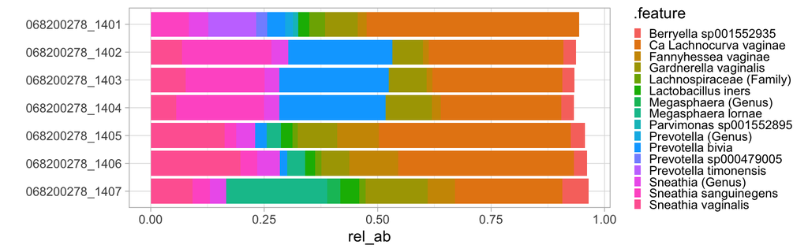

```r
se_16S[, uids_to_check] |>
  as_tibble() |>
  filter(counts > 0, rel_ab > 1 / 100) |>
  ggplot() +
  aes(y = uid |> fct_rev(), x = rel_ab, fill = .feature) +
  geom_col() +
  ylab("") +
  theme(
    strip.text.y = element_text(angle = 0),
    legend.key.size = unit(0.2, "cm")
  )
```

**Important**

Check with the 16S amplicon data generator what the barcode for that sample is.

### Consistency check: barcodes with different assignments across assays

```r
sample_manifest_summary_by_barcode <-
  sample_manifest |>
  filter(!is.na(barcode)) |>
  group_by(barcode) |>
  summarize(
    n = n(),
    n_uids = n_distinct(uid),
    uids = str_c(unique(uid), collapse = ", "),
    sources = str_c(unique(source), collapse = ", "),
    sample_types = str_c(unique(sample_type), collapse = ", "),
    .groups = "drop"
  )

sample_manifest_summary_by_barcode |>
  arrange(-n_uids) |>
  slice_head(n = 10)
```

```
# A tibble: 10 × 6
   barcode     n n_uids uids                           sources      sample_types
   <chr>   <int>  <int> <chr>                          <chr>        <chr>
 1 2286665     2      2 068200385_1205, 068200385_1206 16S_ASV      Clinical sa…
 2 2292179     2      2 068200356_1305, 068200439_1107 16S_ASV      Clinical sa…
 3 1010        3      1 068100011_1400                 mg, qPCR, 1… Clinical sa…
 4 1013        2      1 068100011_1303                 qPCR_daily,… Clinical sa…
 5 1027        3      1 068100016_0000                 mg, qPCR, 1… Clinical sa…
 6 1041        3      1 068100011_1500                 mg, qPCR, 1… Clinical sa…
 7 1046        2      1 068100011_1405                 qPCR_daily,… Clinical sa…
 8 1080        1      1 068100010_1700                 16S_ASV      Clinical sa…
 9 1081        2      1 068100010_1700                 mg, qPCR     Clinical sa…
10 1095        1      1 068100006_2120                 16S_ASV      Clinical sa…
```

There are 2 barcodes that have been assigned to different `uid`s, which is unexpected and may indicate a mislabeling of samples.

#### 2286665

```r
sample_manifest |>
  filter(str_detect(uid, "068200385_120[2-7]")) |>
  arrange(barcode, source) |>
  select(barcode, uid, source)
```

```
# A tibble: 10 × 3
   barcode uid            source
   <chr>   <chr>          <chr>
 1 2286662 068200385_1202 16S_ASV
 2 2286662 068200385_1202 qPCR_daily
 3 2286663 068200385_1203 16S_ASV
 4 2286663 068200385_1203 qPCR_daily
 5 2286664 068200385_1204 16S_ASV
 6 2286664 068200385_1204 qPCR_daily
 7 2286665 068200385_1205 16S_ASV
 8 2286665 068200385_1206 16S_ASV
 9 2286666 068200385_1207 16S_ASV
10 2286666 068200385_1207 qPCR_daily
```

```r
se_16S[, c(
  "068200385_1204",
  "068200385_1205",
  "068200385_1206",
  "068200385_1207"
)] |>
  assay("rel_ab") |>
  head() |>
  round(4)
```

```
                        068200385_1204 068200385_1205 068200385_1206
Lactobacillus crispatus         0.9148         0.9883         0.9561
Ca Lachnocurva vaginae          0.0000         0.0000         0.0001
Lactobacillus iners             0.0000         0.0000         0.0001
Fannyhessea vaginae             0.0000         0.0000         0.0000
Gardnerella vaginalis           0.0000         0.0000         0.0000
Prevotella bivia                0.0016         0.0000         0.0000
                        068200385_1207
Lactobacillus crispatus         0.9383
Ca Lachnocurva vaginae          0.0001
Lactobacillus iners             0.0000
Fannyhessea vaginae             0.0000
Gardnerella vaginalis           0.0001
Prevotella bivia                0.0000
```

The 16S data looks legit and distinct for these two samples…

**Important**

Check with the 16S amplicon data generator what the barcode for that sample is.

Until we have figured this out, we set the barcode of sample `068200385_1206` to NA as it is the one that looks more likely to be mislabelled.

```r
sample_manifest <-
  sample_manifest |>
  mutate(
    barcode = case_when(
      uid == "068200385_1206" ~ NA_character_,
      TRUE ~ barcode
    )
  )
```

#### 2292179

```r
sample_manifest |>
  filter(barcode == "2292179") |>
  arrange(barcode, source) |>
  select(barcode, uid, source)
```

```
# A tibble: 2 × 3
  barcode uid            source
  <chr>   <chr>          <chr>
1 2292179 068200356_1305 16S_ASV
2 2292179 068200439_1107 16S_ASV
```

Again it appears to be something unexpected in the 16S amplicon data…

```r
sample_manifest |>
  filter(str_detect(uid, "068200356_130[4-6]|068200439_110[5-7]")) |>
  arrange(barcode, source) |>
  select(barcode, uid, source)
```

```
# A tibble: 11 × 3
   barcode     uid            source
   <chr>       <chr>          <chr>
 1 2292082     068200356_1304 16S_ASV
 2 2292082     068200356_1304 qPCR_daily
 3 2292086     068200356_1306 16S_ASV
 4 2292086     068200356_1306 qPCR_daily
 5 2292177     068200439_1105 16S_ASV
 6 2292177     068200439_1105 qPCR_daily
 7 2292178     068200439_1106 16S_ASV
 8 2292178     068200439_1106 qPCR_daily
 9 2292179     068200356_1305 16S_ASV
10 2292179     068200439_1107 16S_ASV
11 2292179_C10 068200439_1107 qPCR_daily
```

From this data, it looks like the barcode “2292179” should be assigned to “068200439_1107” and not to “068200356_1305”.

The barcode of “068200356_1305” should likely be “2292083” or “2292085” to follow the logical sequence in barcode numbers, but these two barcodes do not exist:

```r
sample_manifest |>
  filter(barcode %in% c("2292083", "2292085")) |>
  arrange(barcode, source) |>
  select(barcode, uid, source)
```

```
# A tibble: 0 × 3
# ℹ 3 variables: barcode <chr>, uid <chr>, source <chr>
```

We check the 16S data just to be sure that, besides a barcode mislabeling, there is no other issue with the data for these two samples:

```r
uids_to_check <-
  sample_manifest |>
  filter(str_detect(uid, "068200356_130[4-6]|068200439_110[5-7]")) |>
  pull(uid) |>
  sort() |>
  unique()

se_16S[, uids_to_check] |>
  assay("rel_ab") |>
  head() |>
  round(4)
```

```
                        068200356_1304 068200356_1305 068200356_1306
Lactobacillus crispatus         0.0000         0.0000         0.0001
Ca Lachnocurva vaginae          0.0000         0.0000         0.0000
Lactobacillus iners             0.0112         0.0102         0.0129
Fannyhessea vaginae             0.0481         0.0427         0.0818
Gardnerella vaginalis           0.0350         0.0385         0.0341
Prevotella bivia                0.0538         0.0529         0.0697
                        068200439_1105 068200439_1106 068200439_1107
Lactobacillus crispatus         0.0000         0.0000         0.0000
Ca Lachnocurva vaginae          0.1188         0.3017         0.2727
Lactobacillus iners             0.2706         0.1167         0.1263
Fannyhessea vaginae             0.0186         0.0078         0.0130
Gardnerella vaginalis           0.0237         0.0197         0.0144
Prevotella bivia                0.0000         0.0000         0.0000
```

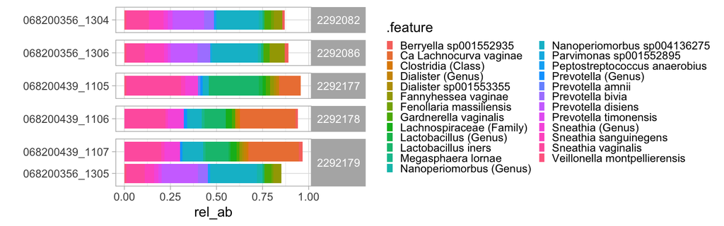

```r
se_16S[, uids_to_check] |>
  as_tibble() |>
  filter(counts > 0, rel_ab > 1 / 100) |>
  ggplot() +
  facet_grid(sample_id_barcode ~ ., scales = "free", space = "free") +
  aes(y = uid, x = rel_ab, fill = .feature) +
  geom_col() +
  ylab("") +
  theme(
    strip.text.y = element_text(angle = 0),
    legend.key.size = unit(0.2, "cm")
  )
```

Fortunately, the `uid` assignments look correct and we can likely consider that the barcode is missing for the `068200356_1305` sample.

**Important**

Check with the 16S amplicon data generator what the barcode for that sample is.

Until we have figured this out, we set the barcode of sample `068200356_1305` to NA as it is the one that looks more likely to be mislabelled.

```r
sample_manifest <-
  sample_manifest |>
  mutate(
    barcode = case_when(
      uid == "068200356_1305" ~ NA_character_,
      TRUE ~ barcode
    )
  )
```

### Consistency check: extraction data

We add the `visit_type` from the `mae_coldata` table to the `sample_manifest` table to check if extraction library plate numbers are unique across all sample types or if they are numbered by sample type (weekly vs daily swabs).

```r
sample_manifest <-
  sample_manifest |>
  select(-any_of("visit_type")) |>
  left_join(
    mae_coldata |> select(uid, visit_type),
    by = join_by(uid)
  )
```

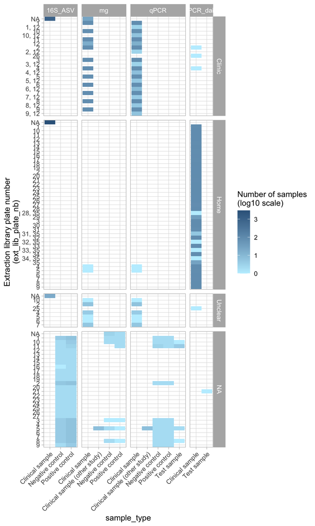

```r
sample_manifest |>
  # filter(sample_type == "Clinical sample") |>
  dplyr::count(source, sample_type, visit_type, ext_lib_plate_nb) |>
  distinct() |>
  ggplot() +
  facet_grid(visit_type ~ source, scales = "free", space = "free") +
  aes(y = ext_lib_plate_nb |> fct_rev(), x = sample_type, fill = n |> log10()) +
  geom_tile() +
  ylab("Extraction library plate number\n(ext_lib_plate_nb)") +
  scale_fill_gradient(
    "Number of samples\n(log10 scale)",
    low = "lightblue1",
    high = "steelblue4"
  ) +
  theme(axis.text.x = element_text(angle = 45, hjust = 1))
```

First, it looks like numbers are not unique across sample types, so we have to specify the extraction batch (weekly or daily swabs) to differentiate between numbers.

```r
sample_manifest <-
  sample_manifest |>
  mutate(
    ext_lib_plate_batch = case_when(
      source == "mg" ~ "Weekly swab",
      source == "qPCR" ~ "Weekly swab",
      source == "qPCR_daily" ~ "Daily swab",
      source == "16S_ASV" ~ "???"
    )
  )
```

In the 16S amplicon data, the extraction library plate numbers are only known for the control samples, but not for the clinical samples.

For the clinic samples (weekly swab), the extraction plate numbers are provided in both the `"mg"` and `"qPCR"` assays. We’ll need to check that they are consistent between the two assays.

For the home samples (daily swabs), the extraction plate numbers are only provided in the `"qPCR_daily"` assay, so we won’t be able to check their consistency across assays.

```r
sample_manifest_summary_by_uid <-
  sample_manifest |>
  filter(!is.na(ext_lib_plate_nb), sample_type == "Clinical sample") |>
  group_by(uid) |>
  summarize(
    n = n(),
    n_ext_batch = n_distinct(ext_lib_plate_batch),
    ext_batches = str_c(
      unique(ext_lib_plate_batch) |> str_replace_na("NA"),
      collapse = " | "
    ),
    n_plate_nb = n_distinct(ext_lib_plate_nb),
    plate_nbs = str_c(
      unique(ext_lib_plate_nb) |> str_replace_na("NA"),
      collapse = " | "
    ),
    n_sources = n_distinct(source),
    sources = str_c(unique(source), collapse = " | "),
    .groups = "drop"
  )
```

We first check if any samples were extracted in the two different batches:

```r
sample_manifest_summary_by_uid |>
  filter(n_ext_batch > 1)
```

```
# A tibble: 2 × 8
  uid           n n_ext_batch ext_batches n_plate_nb plate_nbs n_sources sources
  <chr>     <int>       <int> <chr>            <int> <chr>         <int> <chr>
1 06820012…     2           2 Weekly swa…          2 12 | 4            2 qPCR |…
2 06820041…     2           2 Weekly swa…          2 12 | 26           2 qPCR |…
```

```r
sample_manifest |>
  filter(uid %in% c("068200127_1100", "068200414_1500")) |>
  select(
    uid,
    barcode,
    ext_lib_plate_nb,
    source,
    pcr_plate_nb,
    visit_type,
    ext_lib_plate_batch
  ) |>
  arrange(uid, barcode, source)
```

```
# A tibble: 8 × 7
  uid            barcode ext_lib_plate_nb source     pcr_plate_nb visit_type
  <chr>          <chr>   <chr>            <chr>      <chr>        <chr>
1 068200127_1100 2196631 <NA>             16S_ASV    <NA>         Clinic
2 068200127_1100 2196631 <NA>             mg         <NA>         Clinic
3 068200127_1100 2196631 12               qPCR       <NA>         Clinic
4 068200127_1100 2196631 4                qPCR_daily 04           Clinic
5 068200414_1500 2298406 <NA>             16S_ASV    <NA>         Clinic
6 068200414_1500 2298406 <NA>             mg         <NA>         Clinic
7 068200414_1500 2298406 12               qPCR       <NA>         Clinic
8 068200414_1500 2298406 26               qPCR_daily 26           Clinic
# ℹ 1 more variable: ext_lib_plate_batch <chr>
```

There are two “weekly” samples that were extracted in both batches. For both of these samples, the extraction plate number in the `qPCR` assay is 12, which I think it the plate with the re-extracted samples.

It is unclear if the amplicon sequencing was done on the original extraction or on the re-extracted samples.

**Important**

Ask Joseph about extraction plates for these samples…

& check whether these samples are among the duplicated samples in the original 16S data.

For now, we will assume that the sequencing was done on the re-extracted samples…

Next, we check if there are any samples with more than one extraction plate number.

```r
sample_manifest_summary_by_uid |>
  filter(n_ext_batch <= 1) |>
  dplyr::count(n_plate_nb, sources)
```

```
# A tibble: 4 × 3
  n_plate_nb sources        n
       <int> <chr>      <int>
1          1 mg | qPCR    890
2          1 qPCR          26
3          1 qPCR_daily  2987
4          2 mg | qPCR     51
```

```r
sample_manifest_summary_by_uid |>
  filter(n_ext_batch <= 1) |>
  arrange(-n_plate_nb) |>
  head()
```

```
# A tibble: 6 × 8
  uid           n n_ext_batch ext_batches n_plate_nb plate_nbs n_sources sources
  <chr>     <int>       <int> <chr>            <int> <chr>         <int> <chr>
1 06810000…     2           1 Weekly swab          2 9 | 9, 12         2 mg | q…
2 06810001…     2           1 Weekly swab          2 9 | 9, 12         2 mg | q…
3 06810001…     2           1 Weekly swab          2 9 | 9, 12         2 mg | q…
4 06810001…     2           1 Weekly swab          2 12 | 9, …         2 mg | q…
5 06810002…     2           1 Weekly swab          2 12 | 9, …         2 mg | q…
6 06810003…     2           1 Weekly swab          2 9 | 9, 12         2 mg | q…
```

There are a few samples with two different extraction plate numbers, but all of them are mismatch between the `"mg"` and `"qPCR"` assays, which is not unexpected because in the metagenomics data, Michael only provided the data for the retained extraction, while in the qPCR rate, the data from both extraction were provided.

```r
sample_manifest |>
  filter(uid %in% c("068100006_1400", "068100013_1100")) |>
  select(
    uid,
    barcode,
    ext_lib_plate_nb,
    source,
    pcr_plate_nb,
    visit_type,
    ext_lib_plate_batch
  ) |>
  arrange(uid, barcode, source)
```

```
# A tibble: 6 × 7
  uid            barcode ext_lib_plate_nb source  pcr_plate_nb visit_type
  <chr>          <chr>   <chr>            <chr>   <chr>        <chr>
1 068100006_1400 551     <NA>             16S_ASV <NA>         Clinic
2 068100006_1400 551     9                mg      <NA>         Clinic
3 068100006_1400 551     9, 12            qPCR    <NA>         Clinic
4 068100013_1100 1167    <NA>             16S_ASV <NA>         Clinic
5 068100013_1100 1167    9                mg      <NA>         Clinic
6 068100013_1100 1167    9, 12            qPCR    <NA>         Clinic
# ℹ 1 more variable: ext_lib_plate_batch <chr>
```

#### Imputing extraction plate numbers for amplicon data (and a few missing values in the metagenomics assay)

Since we didn’t have the extraction library plate number for the 16S data, we will use the data from the qPCR assays to fill in the information for the amplicon data.

```r
ext_plate_amplicon <-
  sample_manifest |>
  filter(sample_type == "Clinical sample") |>
  mutate(
    min_plate_nb = ext_lib_plate_nb |> str_remove(",.*") |> parse_number(),
  ) |>
  filter(!is.na(min_plate_nb)) |>
  group_by(uid) |>
  arrange(uid, ext_lib_plate_batch) |>
  mutate(
    n_ext_batches = n_distinct(ext_lib_plate_batch),
    n_plate_nb = n_distinct(min_plate_nb)
  ) |>
  select(
    uid,
    barcode,
    source,
    ext_lib_plate_batch,
    min_plate_nb,
    n_ext_batches,
    n_plate_nb
  ) |>
  arrange(-n_ext_batches, -n_plate_nb, uid, min_plate_nb) |>
  slice_head(n = 1) |>
  ungroup() |>
  mutate(ext_lib_plate_nb = min_plate_nb) |>
  select(uid, ext_lib_plate_batch, ext_lib_plate_nb)
```

```r
sample_manifest <-
  sample_manifest |>
  select(
    uid,
    barcode,
    source,
    sample_type,
    visit_type,
    ext_lib_plate_batch,
    ext_lib_plate_nb
  ) |>
  select(-any_of(ends_with("_new"))) |>
  left_join(
    ext_plate_amplicon |>
      select(
        uid,
        ext_lib_plate_batch_new = ext_lib_plate_batch,
        ext_lib_plate_nb_new = ext_lib_plate_nb
      ),
    by = join_by(uid)
  )
```

```r
sample_manifest <-
  sample_manifest |>
  mutate(
    ext_lib_plate_batch = ifelse(
      (source == "16S_ASV") & !is.na(ext_lib_plate_batch_new),
      ext_lib_plate_batch_new,
      ext_lib_plate_batch
    ),
    ext_lib_plate_nb_origin = ext_lib_plate_nb,
    ext_lib_plate_nb = ifelse(
      ((source == "16S_ASV") & !is.na(ext_lib_plate_nb_new)) |
        ((source == "mg") & is.na(ext_lib_plate_nb)),
      ext_lib_plate_nb_new,
      ext_lib_plate_nb
    ),
    ext_lib_plate_id = ifelse(
      ext_lib_plate_batch != "???",
      str_c(
        ext_lib_plate_batch,
        "s plate ",
        str_pad(ext_lib_plate_nb, width = 2, pad = "0")
      ),
      NA_character_
    ),
    ext_lib_plate_nb_num = ext_lib_plate_nb |>
      str_remove(",.*") |>
      parse_number(),
    ext_lib_info_source = case_when(
      !is.na(ext_lib_plate_nb) &
        (ext_lib_plate_nb == ext_lib_plate_nb_origin) ~ "colData of source assay",
      !is.na(ext_lib_plate_nb) ~ "imputed from qPCR or mg",
      TRUE ~ NA_character_
    )
  ) |>
  arrange(ext_lib_plate_batch, ext_lib_plate_nb_num) |>
  mutate(ext_lib_plate_id = ext_lib_plate_id |> fct_inorder())
```

```r
sample_manifest <-
  sample_manifest |>
  select(
    uid,
    barcode,
    source,
    sample_type,
    visit_type,
    ext_lib_plate_batch,
    ext_lib_plate_nb,
    ext_lib_plate_id,
    ext_lib_info_source
  )
```

```r
sample_manifest |>
  dplyr::count(ext_lib_info_source)
```

```
# A tibble: 3 × 2
  ext_lib_info_source         n
  <chr>                   <int>
1 colData of source assay  5146
2 imputed from qPCR or mg  3979
3 <NA>                        9
```

After imputation, there are still a few samples with missing extraction data:

```r
sample_manifest |>
  filter(is.na(ext_lib_plate_id), sample_type == "Clinical sample")
```

```
# A tibble: 4 × 9
  uid            barcode source  sample_type     visit_type ext_lib_plate_batch
  <chr>          <chr>   <chr>   <chr>           <chr>      <chr>
1 068200278_1404 <NA>    16S_ASV Clinical sample Home       ???
2 068200356_1305 <NA>    16S_ASV Clinical sample Home       ???
3 068200385_1205 2286665 16S_ASV Clinical sample Home       ???
4 068200385_1206 <NA>    16S_ASV Clinical sample Home       ???
# ℹ 3 more variables: ext_lib_plate_nb <chr>, ext_lib_plate_id <fct>,
#   ext_lib_info_source <chr>
```

We impute the plates from these samples from the surrounding samples of the same participant when possible:

```r
sample_manifest |>
  filter(uid |> str_detect("068200356_130[3-7]")) |>
  arrange(uid) |>
  select(uid, barcode, ext_lib_plate_nb, ext_lib_plate_id) |>
  distinct()
```

```
# A tibble: 5 × 4
  uid            barcode ext_lib_plate_nb ext_lib_plate_id
  <chr>          <chr>   <chr>            <fct>
1 068200356_1303 2292080 19               Daily swabs plate 19
2 068200356_1304 2292082 19               Daily swabs plate 19
3 068200356_1305 <NA>    <NA>             <NA>
4 068200356_1306 2292086 19               Daily swabs plate 19
5 068200356_1307 2292088 19               Daily swabs plate 19
```

```r
# 19

sample_manifest |>
  filter(uid |> str_detect("068200385_120[3-7]")) |>
  arrange(uid) |>
  select(uid, barcode, ext_lib_plate_nb, ext_lib_plate_id) |>
  distinct()
```

```
# A tibble: 5 × 4
  uid            barcode ext_lib_plate_nb ext_lib_plate_id
  <chr>          <chr>   <chr>            <fct>
1 068200385_1203 2286663 17               Daily swabs plate 17
2 068200385_1204 2286664 17               Daily swabs plate 17
3 068200385_1205 2286665 <NA>             <NA>
4 068200385_1206 <NA>    <NA>             <NA>
5 068200385_1207 2286666 17               Daily swabs plate 17
```

```r
# 17

sample_manifest |>
  filter(uid |> str_detect("068200278_140[2-7]")) |>
  arrange(uid) |>
  select(uid, barcode, ext_lib_plate_nb, ext_lib_plate_id) |>
  distinct()
```

```
# A tibble: 6 × 4
  uid            barcode ext_lib_plate_nb ext_lib_plate_id
  <chr>          <chr>   <chr>            <fct>
1 068200278_1402 2293839 21               Daily swabs plate 21
2 068200278_1403 2293840 21               Daily swabs plate 21
3 068200278_1404 <NA>    <NA>             <NA>
4 068200278_1405 2293842 22               Daily swabs plate 22
5 068200278_1406 2293843 22               Daily swabs plate 22
6 068200278_1407 2293844 22               Daily swabs plate 22
```

```r
# 21 or 22
```

```r
sample_manifest |>
  filter(
    ext_lib_plate_batch == "Daily swab",
    sample_type == "Clinical sample"
  ) |>
  select(uid, barcode, ext_lib_plate_nb) |>
  distinct() |>
  dplyr::count(ext_lib_plate_nb) |>
  ggplot() +
  aes(x = ext_lib_plate_nb, y = n) +
  geom_label(aes(label = n), size = 3)
```

[output not shown]

```r
sample_manifest <-
  sample_manifest |>
  mutate(
    ext_lib_plate_batch = case_when(
      uid %in%
        c(
          "068200278_1404",
          "068200356_1305",
          "068200385_1205",
          "068200385_1206"
        ) ~ "Daily swab",
      TRUE ~ ext_lib_plate_batch
    ),
    ext_lib_plate_nb = case_when(
      uid == "068200278_1404" ~ "21", # not sure...
      uid == "068200356_1305" ~ "19", # not sure....
      uid == "068200385_1205" ~ "17",
      uid == "068200385_1206" ~ "17",
      TRUE ~ ext_lib_plate_nb
    ),
    ext_lib_plate_id = case_when(
      uid == "068200278_1404" ~ "Daily swabs plate 21" |>
        factor(levels = levels(ext_lib_plate_id)),
      uid == "068200356_1305" ~ "Daily swabs plate 19" |>
        factor(levels = levels(ext_lib_plate_id)),
      uid == "068200385_1205" ~ "Daily swabs plate 17" |>
        factor(levels = levels(ext_lib_plate_id)),
      uid == "068200385_1206" ~ "Daily swabs plate 17" |>
        factor(levels = levels(ext_lib_plate_id)),
      TRUE ~ ext_lib_plate_id
    ),
    ext_lib_info_source = case_when(
      uid %in%
        c(
          "068200278_1404",
          "068200356_1305",
          "068200385_1205",
          "068200385_1206"
        ) ~ "imputed from surrounding samples of the same participant",
      TRUE ~ ext_lib_info_source
    )
  )
```

```r
sample_manifest <-
  sample_manifest |>
  select(
    uid,
    barcode,
    source,
    ext_lib_plate_batch,
    ext_lib_plate_nb,
    ext_lib_plate_id,
    ext_lib_info_source
  ) |>
  arrange(source, ext_lib_plate_id, uid)
```

```r
sample_manifest |>
  dplyr::count(ext_lib_info_source)
```

```
# A tibble: 4 × 2
  ext_lib_info_source                                          n
  <chr>                                                    <int>
1 colData of source assay                                   5146
2 imputed from qPCR or mg                                   3979
3 imputed from surrounding samples of the same participant     4
4 <NA>                                                         5
```

## Creating the `MultiAssayExperiment` object

```r
SE_list <-
  list(
    visit_and_sample_info = se_sample_and_visit_info_assay,
    mg = se_mg,
    qPCR = se_qPRC,
    qPCR_daily = se_daily_qPRC,
    amplicon_ASV = se_16S_ASV,
    amplicon = se_16S,
    luminex = se_luminex,
    flow = se_flow
  )


mae <-
  MultiAssayExperiment::MultiAssayExperiment(
    experiments = MultiAssayExperiment::ExperimentList(SE_list),
    colData = mae_coldata |>
      select(-in_CRF, -in_assays) |>
      as.data.frame() |>
      mutate(rownames = uid) |>
      column_to_rownames("rownames"),
    metadata = list(
      study = "VIBRANT",
      data_source = "actual study data (not simulated)",
      data_status = "partially QCed",
      date = today(),
      colData_dictionary = coldata_dictionary,
      crf_plates_description = crf_plates_dictionary,
      crf_data_raw = crf_raw,
      crf_data_clean = crf_clean,
      participant_crfs_merged = participant_crfs_merged,
      visits_crfs_merged = visits_crfs_merged,
      exposures = exposures,
      sample_manifest = sample_manifest |>
        select(uid, barcode, source_assay = source, starts_with("ext_lib_"))
    )
  )
```

```r
mae
```

```
A MultiAssayExperiment object of 8 listed
 experiments with user-defined names and respective classes.
 Containing an ExperimentList class object of length 8:
 [1] visit_and_sample_info: SummarizedExperiment with 10 rows and 5463 columns
 [2] mg: SummarizedExperiment with 779 rows and 996 columns
 [3] qPCR: SummarizedExperiment with 16 rows and 1029 columns
 [4] qPCR_daily: SummarizedExperiment with 16 rows and 2990 columns
 [5] amplicon_ASV: SummarizedExperiment with 283061 rows and 4119 columns
 [6] amplicon: SummarizedExperiment with 817 rows and 4119 columns
 [7] luminex: SummarizedExperiment with 48 rows and 850 columns
 [8] flow: SummarizedExperiment with 11 rows and 356 columns
Functionality:
 experiments() - obtain the ExperimentList instance
 colData() - the primary/phenotype DataFrame
 sampleMap() - the sample coordination DataFrame
 `$`, `[`, `[[` - extract colData columns, subset, or experiment
 *Format() - convert into a long or wide DataFrame
 assays() - convert ExperimentList to a SimpleList of matrices
 exportClass() - save data to flat files
```

# Available assays

```r
mae_sample_map <-
  mae@sampleMap |>
  as_tibble() |>
  dplyr::filter(assay %in% assay_list$mae_assay_name) |>
  select(uid = primary, assay) |>
  arrange(uid) |>
  dplyr::left_join(
    assay_list |> dplyr::rename(assay = mae_assay_name),
    by = join_by(assay)
  ) |>
  dplyr::right_join(
    mae@colData |>
      as.data.frame() |>
      as_tibble() |>
      select(
        uid,
        pid,
        visit_code,
        PIPV,
        visit,
        visit_type,
        sample_type,
        location,
        randomized,
        arm
      ),
    by = join_by(uid)
  )
```

All samples

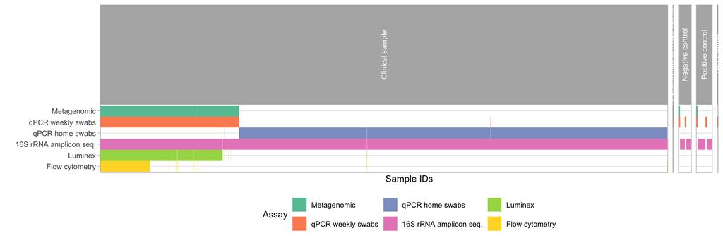

```r
mae_sample_map |>
  dplyr::filter(!is.na(assay), assay != "amplicon_ASV") |>
  group_by(uid) |>
  mutate(n = n()) |>
  ungroup() |>
  mutate(uid = uid |> fct_reorder(-n)) |>
  ggplot() +
  aes(x = uid, y = assay_label |> fct_rev(), fill = assay_label) +
  geom_tile() +
  facet_grid(. ~ sample_type, scales = "free_x", space = "free_x") +
  scale_x_discrete("Sample IDs", breaks = NULL) +
  ylab("") +
  scale_fill_brewer("Assay", type = "qual", palette = 7) + # 3
  theme(
    axis.text.x = element_text(angle = 45, hjust = 1),
    strip.text.x = element_text(angle = 90),
    legend.position = "bottom"
  )
```

Longitudinal availability for all visits

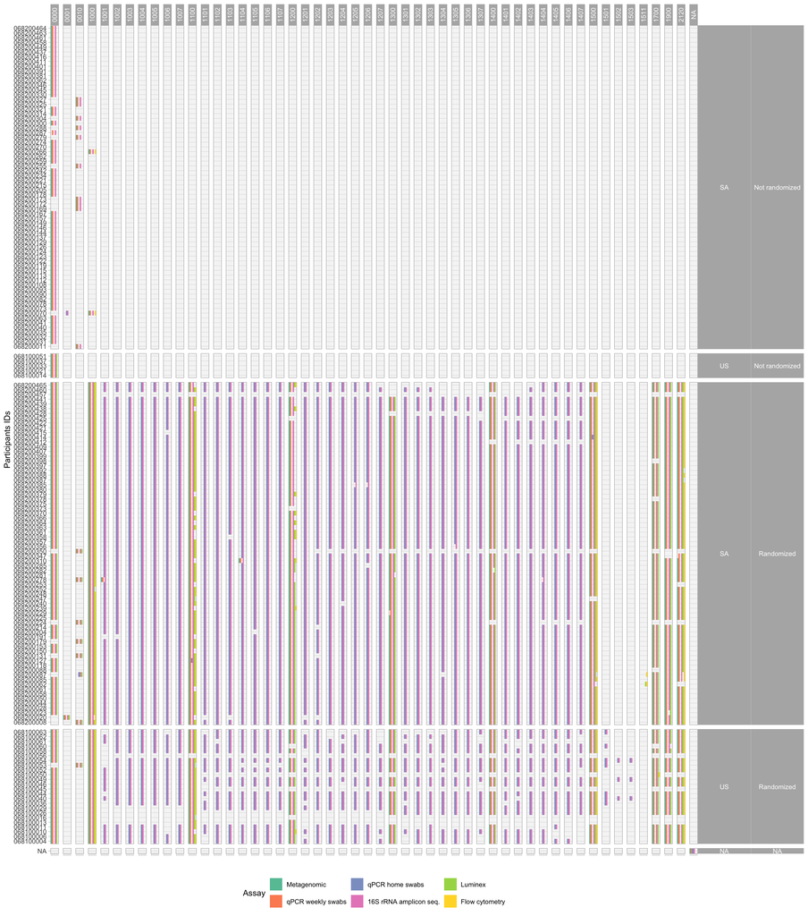

```r
mae_sample_map |>
  dplyr::filter(!is.na(assay), assay != "amplicon_ASV") |>
  # filter(visit_code %in% c("0000", seq(1000, 1900, by = 100), "2120")) |>
  ggplot() +
  aes(x = assay_label, y = pid, fill = assay_label) +
  geom_tile() +
  facet_grid(
    ifelse(randomized, "Randomized", "Not randomized") + location ~ visit_code,
    scales = "free_y",
    space = "free_y"
  ) + # sample_category
  scale_y_discrete("Participants IDs") + #, breaks = "NULL")  +
  xlab("") +
  scale_fill_brewer("Assay", type = "qual", palette = 7) + # 3
  theme(
    axis.text.x = element_blank(), #element_text(angle = 45, hjust = 1),
    strip.text.y = element_text(angle = 0),
    strip.text.x = element_text(angle = 90),
    legend.position = "bottom"
  )
```

For the weekly visits of all participants

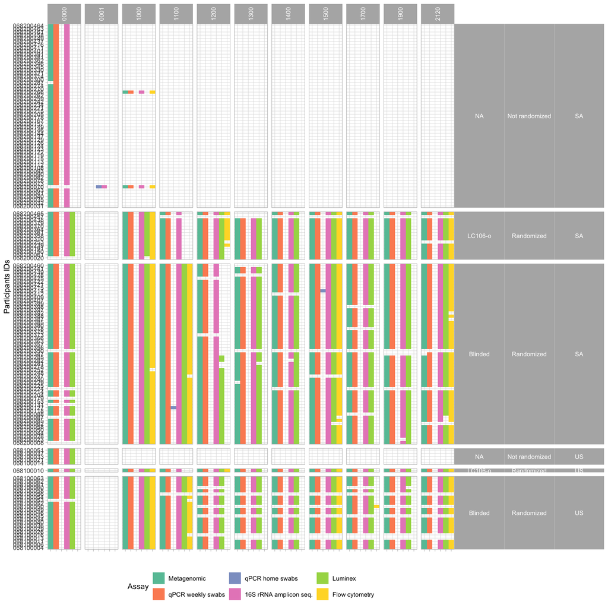

```r
mae_sample_map |>
  dplyr::filter(!is.na(assay), assay != "amplicon_ASV") |>
  dplyr::filter(visit_type == "Clinic") |>
  ggplot() +
  aes(x = assay_label, y = pid, fill = assay_label) +
  geom_tile() +
  facet_grid(
    location +
      ifelse(randomized, "Randomized", "Not randomized") +
      arm ~ visit_code,
    scales = "free_y",
    space = "free_y"
  ) + # sample_category
  scale_y_discrete("Participants IDs") + #, breaks = "NULL")  +
  xlab("") +
  scale_fill_brewer("Assay", type = "qual", palette = 7) + # 3
  theme(
    axis.text.x = element_blank(), #element_text(angle = 45, hjust = 1),
    strip.text.y = element_text(angle = 0),
    strip.text.x = element_text(angle = 90),
    legend.position = "bottom"
  )
```

For the weekly visits of randomized participants

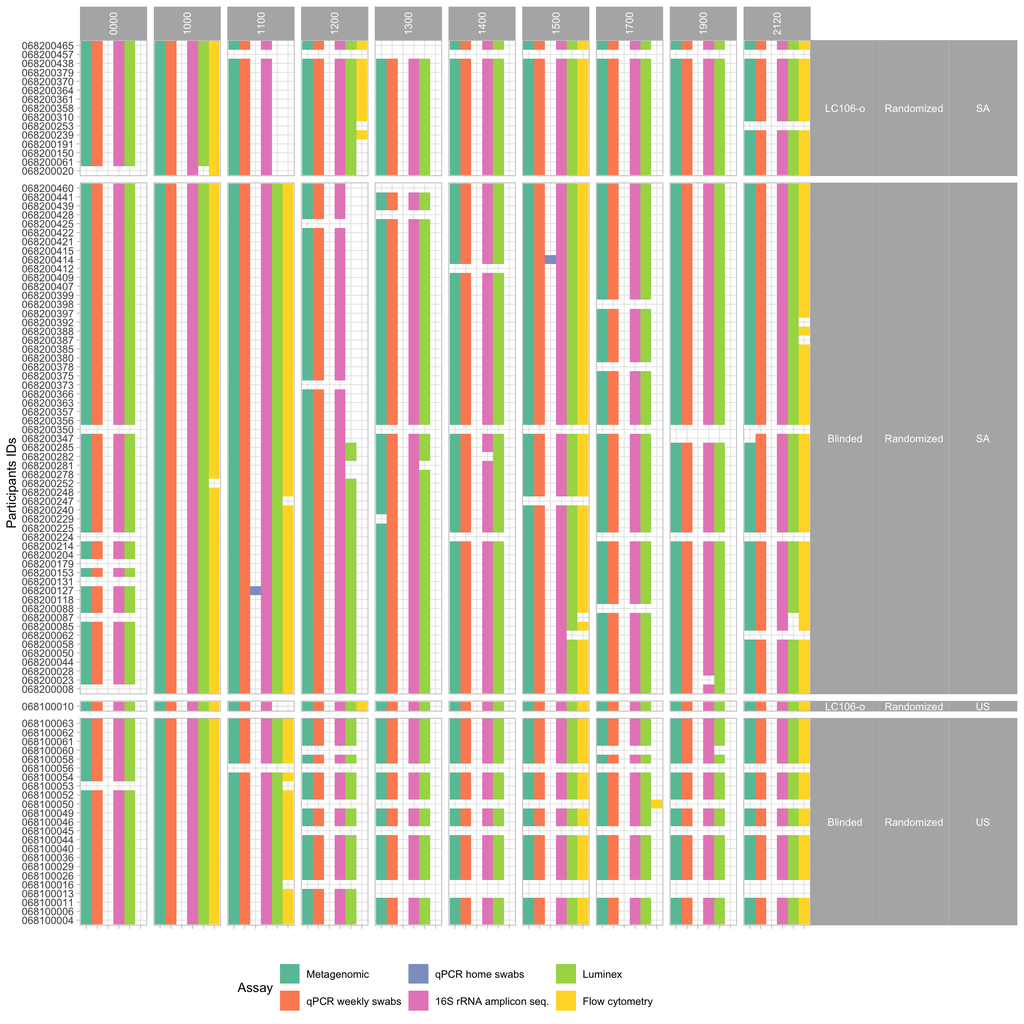

```r
mae_sample_map |>
  dplyr::filter(randomized) |>
  dplyr::filter(!is.na(assay), assay != "amplicon_ASV") |>
  dplyr::filter(visit_type == "Clinic") |>
  ggplot() +
  aes(x = assay_label, y = pid, fill = assay_label) +
  geom_tile() +
  facet_grid(
    location +
      ifelse(randomized, "Randomized", "Not randomized") +
      arm ~ visit_code,
    scales = "free_y",
    space = "free_y"
  ) + # sample_category
  scale_y_discrete("Participants IDs") + #, breaks = "NULL")  +
  xlab("") +
  scale_fill_brewer("Assay", type = "qual", palette = 7) + # 3
  theme(
    axis.text.x = element_blank(), #element_text(angle = 45, hjust = 1),
    strip.text.y = element_text(angle = 0),
    strip.text.x = element_text(angle = 90),
    legend.position = "bottom"
  )
```

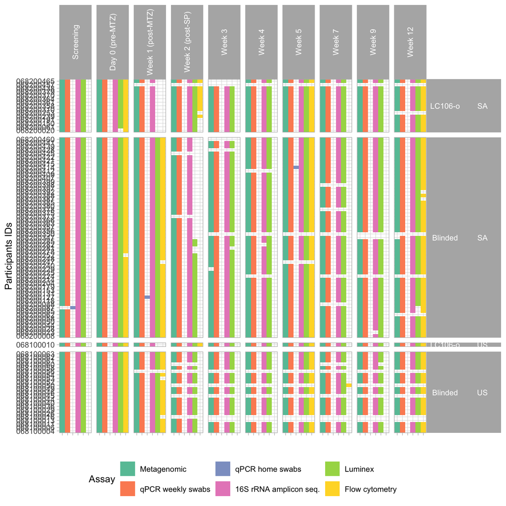

```r
mae_sample_map |>
  dplyr::filter(randomized) |>
  dplyr::filter(!is.na(assay), assay != "amplicon_ASV") |>
  dplyr::filter(PIPV) |>
  ggplot() +
  aes(x = assay_label, y = pid, fill = assay_label) +
  geom_tile() +
  facet_grid(
    location + arm ~ visit,
    scales = "free_y",
    space = "free_y"
  ) + # sample_category
  scale_y_discrete("Participants IDs") + #, breaks = "NULL")  +
  xlab("") +
  scale_fill_brewer("Assay", type = "qual", palette = 7) + # 3
  theme(
    axis.text.x = element_blank(), #element_text(angle = 45, hjust = 1),
    strip.text.y = element_text(angle = 0),
    strip.text.x = element_text(angle = 90),
    legend.position = "bottom"
  )
```

# Saving the `MultiAssayExperiment` objects

We export the full `MultiAssayExperiment` object as an `.rds` file for further analyses.

```r
saveRDS(
  mae,
  str_c(
    get_02_output_dir(),
    "mae_full_",
    today() |> str_remove_all("-"),
    ".rds"
  )
)
```